# Edinburgh University Coursera MOOC Data Exploring Tie Type and Centrality Measures in Forum Activity Networks - Correlation, Independence and Usefulness

Adam Cooper, Cetis, University of Bolton, November 2013

## Background

### Structure of the Forums

In the Coursera courses run from January 28<sup>th</sup> 2013, the forums are structured in the following hierarchical pattern. Each course contains several forums, which may be hierarchically arranged, within which there are typically many threads. Both forums and threads have a title but no content. Forum posts always appear in threads and may have any number of comments attached. There is no hierarchical structure in the comments, hence it is not possible to determine from the data whether a comment is in reply to the post it is associated with, or is in reply to a previous comment. Similarly, it is likely that a reply to a post appears as a new post in the thread; the absence of a comment in the foums data does not mean no-one actually commented or replied. Given the structure of the forums, it would be likely that a reply to the first post in a thread would appear as a new post. In short: both comments and posts may be used to reply to a previous post or comment.

Data on what people read in the forums is only recorded at the level of the thread; it is not possibe to determine which of the various posts in a given thread were actually read, if any.

### Defining the Activity Networks

In order to translate patterns of activity into some kind of network for analysis, it is necessary to define a rule for what decides a connection between people and to give an interpretation of what a connection means. In what follows, following social network analysis conventions, the word “tie” is used to refer to the connections that are inferred from forum activity data and the word “node” will usually be used to refer to a person in the network.

The nature of the forum activity data limits the kinds of statement that may reasonably be made from it about connections between people. Given this fact, a tie should be interpreted as indicating two people have a common interest in some text, although this common interest may be a dispute. In the analysis presented here, no attempt is made to translate this to a common interest in a topic; i.e. there is no mapping between pieces of text according to their subject matter.

Three models for what constitues a tie have been explored.

**Poster-Commenter**  
The assumption of “Poster-Commenter” that a tie between individuals is defined by a comment on a post. This is a directed tie from the commenter to the poster. A tie is assumed if there are 1 or more comments and ties are **not** weighted by the number of comments. Self-commenting (loops) are ignored; self-comments may indicate a discussion with a prior commenter, which may be of interest to a more detailed look at interaction patters.

**Post-Set**  
The assumption of “Poster-Set” is that a tie between individuals is defined by the group of people who contributed a post and any comments. All these people have a tie so this is an undirected network. Ties are are not weighted by the number of comments by the same person and self-commenting (loops) are ignored.

**Whole-Thread**  
The assumption is similar to Post-Set but a tie is defined as being between all people who contributed at least a threshold number of posts or comments to a thread.

These three models represent different points in a trade-off between a desire to extract information that differentiates individuals with a recognition that the structure of the forums, and the behaviour promoted by this structure and its presentation, partially obscures the information needed to discriminate. In particular, the empirical fact that posts and comments are sometimes used interchangably means that the semantic difference between them only applies on aggregate and not necessarily at the level of individuals. Some aspects of the trade-off conclude this section.

**Whole-Thread** represents a total neglect of difference between posts and comments. It has the advantage of being at the same level of aggreagation as forum reading, which is recorded at thread level, corresponding with web page presentation. It also has the advatange of avoiding spurious attribution of effect to comments *vs* posts but the disadvantage that it obliterates any such effect. In the absence of a threshold, people are more likely to be connected than for the other tie models simply because there are more contributions to a thread than comments on a single post. This model will naturally lead to quite dense networks if the threshold is one contribution and brings a notable computational disadvantage; storing the network to disk for further processing requires multi-megabyte files and processing times are in the tens of minutes per course. A threshold of 1 risks causing a very homogeneous network in which most people who contributed more than once have fairly similar network environments but larger thresholds offer an opportunity to be more discriminating and to local meso-scale structures.

Although not considered in this report, the Whole-Thread tie model could be modified to include a weighting factor on the ties according to some function of the number different threads in which a user exceeds the inclusion threshold. This would allow a better differentiation between individuals when centrality measures are calculated and could be used with a threshold to simplify network visualisations.

**Post-Set** assumes that a post is the unit of activity but does not differentiate between comments and the parent post when assigning ties. It has the disadvantage that it will fail to account for posts that are really in reply to another post but has the advantage that it will recover more of the difference between interests. A post with many comments will lead to a very dense region in the network. The network as a whole will be less dense than Whole-Thread; this will ease computation and could lead to a less homogeneous network, hence more differentiation.

**Poster-Commenter** aims to recover more information than a common interest in some text by encoding the idea of “in reply to”. While we know that not all replies appear as comments and that not all comments are replies, it is not the case that all comments are not replies. This method has the disadvantage that, for people who make few contributions, the network statistics calculated for them are unreliable, but the advantage that it may be able to expose active reciprocation. A Poster-Commenter network will be the most sparse since there will be no tie between two commenters on a post. Although Poster-Commenter is attractive in that it encodes behaviour that is closer to the intentions of forum contributors, the reality of what is captured in the data raises serious questions about the validity of this tie model at the level of the individual. It may, however, still provide useful statistics at the level of a course or forum.

The key question to ask is whether these tie models permit meaningful difference in various measures to be determined, whether these differences relate to per-person properties, meso-scale network structures, or whole-network character.

### Centrality Measures Used

Three centrality measures are considered.

- **Degree** is the number of different people an individual has ties with, which can be separated to “in” and “out” for directed graphs. It is conceptually the most simple of the centrality measures, giving a measure of diversity of interaction. It does not, however, account for the number of posts or comments; a pair of people who have communicated with each other (and to no-one else) once and a similar pair who have communicated many times will both have degree=1.
- **Betweenness** captures the extent to which paths between nodes pass through a given node (when taking the shortest path). An individual with a high betweenness centrality will be found to connect one or more groups. Betweenness is an important concept when considering brokerage of ideas between two groups and the influence this may confer. In the context of MOOC forums, which are open to all participants, betweenness is better seen as an indicator of the breadth of activity of an individual **relative** to other course participants.
- **Eigenvector** centrality aims to weight the centrality measure for an individual according to the centrality of people near to them. Individuals with high eigenvector centrality are embedded in dense parts of a network. Such individuals are expected to have a relatively high degree centrality but the reverse is not true; a person with high degree that is connected to many people with low degree will have low eigenvector centrality. In the context of MOOC forums, high eigenvector centrality is likely to indicate exposure to the widest range of ideas expressed in the forums because ideas are likely to be passed on, augmented, reworked, etc between different forums, posts and threads.

All of these measures can be calculated either taking account of the direction of ties, in directed networks, or ignoring direction. The undirected measures will be used for comparison, since the “Post-Set” tie model gives an undirected network.

Closeness centrality is not used because the values show little spread (in practice, only a few distinct values are seen).

## Analysis

### Whole-Network Statistics

| id | No. nodes | P-C Density/% | P-Set Density/% | W-T Density/% (Thresh=4) | W-T Density/% (Thresh=3) | W-T Density/% (Thresh=2) | W-T Density/% |
| --- | --- | --- | --- | --- | --- | --- | --- |
| aiplan | 499 | 0.1489 | 0.2769 | 0.0322 | 0.1030 | 0.1867 | 10.097 |
| astro | 3889 | 0.0341 | 0.1508 | 0.0238 | 0.0601 | 0.1416 | 8.818 |
| crit | 4688 | 0.0111 | 0.0743 | 0.0068 | 0.0368 | 0.1538 | 9.527 |
| edc | 2544 | 0.0544 | 0.3818 | 0.0295 | 0.1052 | 0.3639 | 14.457 |
| equine | 6244 | 0.0127 | 0.0495 | 0.0040 | 0.0121 | 0.0432 | 6.195 |
| intro | 6989 | 0.0176 | 0.0978 | 0.0198 | 0.0536 | 0.1268 | 5.982 |

The effect on density that was outlined in the description of the different tie models is evident, although it is also clear that there are differences between courses when the same tie model is used. These differences are not simply a direct consequence of network size, by the definition of network density.

The Whole-Thread model with no threshold produces networks of exceptionally high density. E-learning and Digital Cultures has around 1 in 7 of the total possible ties. At this level, it is highly unlikely that any interesting differences between individuals or groups of individuals would be discovered. The range of values between courses is also the least of the three models, less than a factor of three compared with almost a factor of 10 for Whole-Thread with a threshold of three. It is, therefore, less discriminating at the network level also.

The following parallel coordinate plot shows how each of the density measures and the number of nodes vary for each course, with each quantity being separately scaled and fit within the vertical range of the plot. This appears to show that there may be a secondary effect of network size on density; course with more participants do generally have a lower density in the Poster-Commenter tie model. If AI Planning (red line) is discounted, however, the aparrent pattern does not appear.

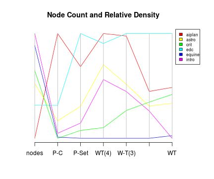

The parallel coordinate plot is useful because it shows whether the different courses are similarly placed as the tie model changes, i.e. that we would be likely to draw similar conclusions independent of the tie model. The Whole-Thread tie model without a threshold is most visibly at odds with the general pattern but the relative density values between courses with a threshold of two are similar to it. A tentative conclusion might be that if network structure is sought, using Whole-Thread with a threshold of 2 may be subject to the same “washing-out” problem as without a threshold, even though the absolute value densities are less than 1%.

The Post-Set and Whole-Thread tie models with a threshold are reasonably similar, and with the exception of AI planning, also similar to Poster-Commenter. It might be tentatively suggested that this difference is grounded in different behaviour in the forums; AI Planning participants may have more explicitly commented-on posts.

In summary: at the network level, all of the tie models appear to be acceptable with the exception of Whole-Thread without a threshold. The Poster-Commenter model stands slightly apart from the other tie models and may be usefully discriminating some directed commenting behaviour, consistent with its definition.

### Correlation Between Measures

In practice, the different centrality measures for a number of people in a network are unlikely to be independent. Random variation or real-world meso-scale structures both mean that an individual with very high degree centrality, for example, may not also have a very high betweenness centrality. As network size increases, the effect of randomness diminishes but the effect of any real-world structures remains to become more visible as the variance due to the random effects decreaases.

As previously mentioned, a desirable tie model permits discrimination of meso-scale structure. This motivates an inspection of the extent to which the different tie models reveal deviations from randomness in the observed networks.

#### Baseline Simulated Networks

For comparison, a simulated network is generated with ties assigned randomly such that the probability of any two nodes being connected equal is to that in the observed network. In this case, “randomly” means that the probability of two nodes being connected is independent of node attributes and their prior ties and position in the network. This is referred to as an Erdős–Rényi model network.

For example, the following plots show Erdős–Rényi networks to match the node and edge count for the Astrobiology course using a Post-Set tie model. The square root of each measure is plotted to compress the long tails in the distributions.

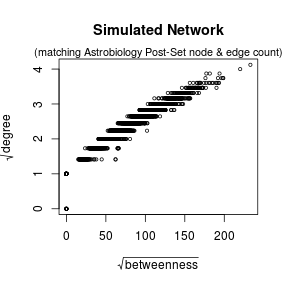

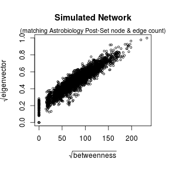

The essentially uniform nature of an Erdős–Rényi network means that there is a tendency for the measures to correlate that would not be observed in a network where there is differentiation. For example, it is conceivable that real-world social networks would have people whose betweenness centrality is higher than the norm but whose eigenvector centrality is lower, and *vice versa*.

The equivalent plots for the Whole-Thread (threshold=3) case, which has the same number of nodes (3889) but fewer ties (4543 compared to 11402), illustrates the non-independence of the measures while also showing it to be less well-defined.

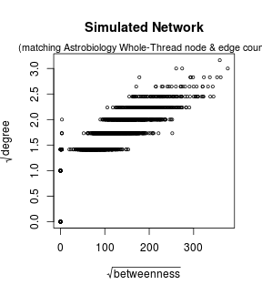

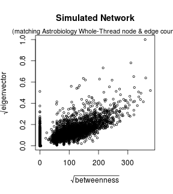

Since these are single simulated networks, they show random variation that would differ from what would be obtained if the simultion were repeated. They do, however, provide a baseline to qualitatively judge whether or not the observed networks contain structures or other evidence of social process, behavioural patterns, etc. This, in turn, permits the tie models to be evaluated for their ability to illuminate such structures. Since the tie models do not contain rules likely to create artificial structures, any evident structure can be assumed to be real, but subject to limitations of what may be inferred from them as discussed in the description of the tie type models.

#### Observed Networks Under the Tie Models

The three centrality measures are considered for each of the three tie models, with a threshold of three being chosen for the Whole-Thread model as a sensible mid-point between the over-dense nature of the threshold-free case and the rather sparse case when the threshold is four. For some network analysis questions, a higher threshold might be useful to “tune in” to peaks of activity but a side-by-side comparison of the tie models will be aided if the network densities are broadly similar.

Astrobiology is chosen for illustration; consult the parallel coordinate plot to see that it is a reasonable estimate for the median case in terms of the combined set of attributes. The following plots show how each pair of measures correspond for each node (person) in the network. Note that the scales differ between each tie model. The plots corresponding to the simulations appear in the middle of the top and bottom rows, for which \( \sqrt{betweenness} \) is the horizontal axis.

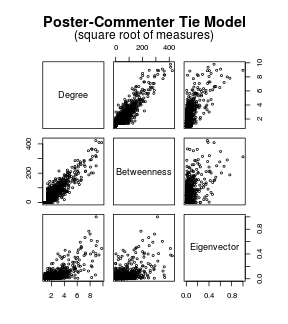

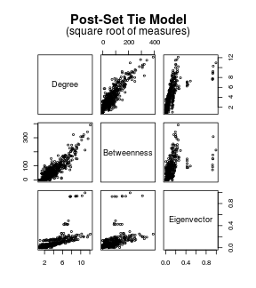

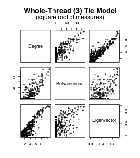

An aspect of all of these plots is that rather more of the points are distributed towards the lower centrality measures. This is also present in the simulated networks but it is expected to be increased in the observed data since people who ceased to participate during the course are included, although the extent of the effect may be influenced by other factors. A careful inspection of the plots shows, however, that there is a markedly longer tail of higher degree centrality for the observed data compared to the equivalent simulation. All tie models appear to be capturing at least some element of non-uniform behaviour. The longer tail relative to the simulated network may simply arise from the fact that the simulation used the mean network density of the observed data; this mean is made low by the presence of people who stopped participating.

The **Poster-Commenter** tie model indicates a clear correlation between degree and betweenness cenrality measures and a great majority of people with low eigenvector centrality measures. In other words, neither betweenness nor eigenvector centrality is revealing features of interest. Except for the longer tail of degree centrality compared to the simulation, the Poster-Commenter tie model seems to afford little insight into the network structure, although taken by itself we might conclude the actual structure is not far from the baseline.

The **Post-Set** tie model shows a decidedly different relationship between betweenness and degree centrality measures for individuals; there are clearly a number of people with upper-middle levels of degree centrality whose betweenness is low. Thes represent regions in the network where people are locally highly connected but not well embedded in the overall network. One striking feature of the Post-Set plots is the appearance of two subsidiary clusters of people in the eigenvector centrality distribution for the Post-Set model. A similar effect is observed for some of the other courses. These are discussed briefly in a subsequent section; although the Post-Set model does not *prime facie* appear to introduce false structures, these appear to be artefacts of the method. So, although the Post-Set model appears to give more evidence for non-uniform network structure, questions remain about the extent to which it may give spurious prominence to these elements.

The **Whole-Thread** model shows a similar spread of degree for low betweenness individuals as does Post-Set and an interestingly different pattern of eigenvector centrality to either the simulated cases or the other tie models. There is clearly a lot less dependence between these two centrality measures; Whole-Thread, with a threshold of three, appears to be discrimiating between people who are embedded in highly connected regions from those who connect regions within the network. It does not show the suspected artefacts of Post-Set. The clear correlation between degree and eigenvector centrality suggests that relatively little insight would be gained from using both measures in analysis.

Although caution should be exercised with interpreting correlation coefficients for these statistics (see “Technical Notes”, below), they provide an interesting counterpart to the above plots. A value of 0 indicates no correlation and +/-1 indicates pure positive or negative correlation (all points follow a line, which need not be straight). Note that correlation fails to discriminate between quite different betweenness:eigenvector relationship patterns.

| id | degree:betweenness | degree:eigenvector | beteenness:eigenvector |
| --- | --- | --- | --- |
| Poster-Commenter | 0.9288 | 0.6367 | 0.5244 |
| Post-Set | 0.7163 | 0.8079 | 0.5794 |
| Whole-Thread(3) | 0.5481 | 0.7336 | 0.5136 |
| Simulated (W-T) | 0.9384 | 0.6553 | 0.7432 |

*Spearman rank correlation values for square root centrality measures*

The tentative conclusion drawn from the above is that betweenness centrality and one of degree or eigenvector centrality - using the Whole-Thread tie model with a threshold of three - would provide the most useful parsimonious set of statistics.

### Principal Components - Another View on Dependence

Principal Component Analysis (PCA) is a widely used approach to deal with multiple attributes which may have strong dependency between them. It is commonly used to reduce from many partially-dependent attributes to a smaller number of mutually-independent attributes by taking linear combinations of the original attributes; the linear combinations are ranked according to the extent to which they account for the variation in the data.

In the present case, we do not have a problem that requires this kind of dimensionality reduction but we do have non-independent attributes and an inkling in the above tentative conclusion that only two could be a useful parsimonious set. PCA is used here to summarise non-independence between the centrality measures and to further investigate this aspect of the tentative conclusion.

Considering the case of the Whole-Thread tie model with a threshold of three, three principal components may be derived from the three centrality measures by using the following linear combinations:

| id | PC1 | PC2 | PC3 |
| --- | --- | --- | --- |
| \( \sqrt{degree} \) | 0.6070 | -0.2242 | -0.7624 |
| \( \sqrt{betweenness} \) | 0.5395 | 0.8207 | 0.1883 |
| \( \sqrt{eigenvector} \) | 0.5835 | -0.5256 | 0.6191 |

These principal components account for 80.4%, 14.5%, 5.1% of the variance in the data. Hence, the variation between individuals is largely explained by a single component (PC1) that is composed from approximately equal measures of each centrality measure. This could be described as a broad measure of extent participation. **NB: a PCA should be conducted with the number of contributions as a statistic to determine whether PCA1 is essentially equivalent to it.** The second principal component (PC2) is mostly influenced by the betweenness centrality, which is has a positive weighting in contrast to the negative weighting for eigenvector centrality. This indicates that, for this component, lower values of betweenness centrality are associated with higher values eigenvector centrality and *vice versa* (it is the relative sign difference that is important). This could be interpreted as a measure of the extent to which a person is embedded in *vs* between regions of network density, conditional on PCA1.

The following plot shows how individuals are distributed according to the first two primary components. It also shows in red how the centrality measures relate to these two primary components, providing a more visual means of interpreting the previous table.

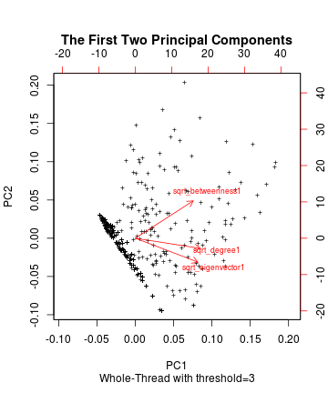

The red vectors emphasise the previously-made comment about betweenness centrality standing relatively distinct from the more-similar other two measures and might suggest that the best choice of two centrality measures out of the three would be degree and betweenness since these most closely align with the first two principal components. The weakness with this approach is that the centrality measures are not independent. An alternative approach, which would be useful when the non-independence is an issue, would be to use PCA1 and PCA2 for further analysis, since together they account for 95% of variance. This has the distinct disadvantage in that it gives us statistics that are not directly interpretable in terms of well-known ideas such as “degree” or “betweenness”. Hence it may be necessary to transform the components back to centrality measure space.

### A Closer Look at the Whole-Thread Threshold

The question of threshold choice is analogous to choosing a height to designate something a mountain, when deciding whether or not a region is mountainous. If the threshold is set too low, the process is insufficiently discriminating and a region with many rolling hills could appear to be more mountainous than the alps. In both the analogy and the case of the Whole-Thread tie model, there is an element of subjectivity and a necessity to consider the purpose at hand.

A high threshold will naturally identify the structures created by the most active course participants, for whom we can have the most confidence that the network is representative of their behaviour. The consequence, however, is that many participants effectively vanish because they are not connected in a high-threshold network. A low threshold includes people with less activity but leads to a network that may be a less reliable representation of behaviour simply because there are fewer data points.

| id | No. nodes | Threshold=4 Isolates/% | Threshold=3 Isolates/% | Threshold=2 Isolates/% | No Threshold Isolates/% |
| --- | --- | --- | --- | --- | --- |
| aiplan | 499 | 94.99 | 87.98 | 80.16 | 1.804 |
| astro | 3889 | 91.36 | 84.78 | 75.42 | 2.031 |
| crit | 4688 | 96.44 | 92.19 | 84.58 | 12.009 |
| edc | 2544 | 90.88 | 83.57 | 70.72 | 3.774 |
| equine | 6244 | 96.03 | 91.56 | 83.01 | 20.115 |
| intro | 6989 | 91.00 | 84.85 | 76.52 | 9.057 |

*Proportion of forum contributors without ties for different threshold levels in the Whole-Thread tie model.*

For the degenerate no-threshold case, isolates are people who only posted to a thread that never received any further contributions. All courses show essentially the same progression as the threshold is increased with similar change moving from four to three, and from three to two. This suggests that threshold values from two upwards can be used for progressive attenuation of less significant structure.

The previous observations lead to the intuition that the threshold should be set at the largest value which does not exclude too many people in the view of the investigator, taking into account the purpose of the investigation. Three example fragment sociograms appear below for the Astrobiology course. Nodes are colour-coded according to geographical region (unfortunately the colours are assigned automatically by Gephi so do not match between diagrams, but the equivalent region is shown). In this case, the majority colour indicates a participant from South America. Isolates are hidden and the plots are shown in progressive order of threshold from two to four.

[figure not shown]

In this particular case the use of different threshold levels shows a community with both core and connecting members almost exclusively coming from South America. A threshold of two is sufficient to discern the network sub-structure while the higher thresholds demonstrate the extent of cohesion.

### A Closer Look at Clusters in Eigenvector Centrality

Several of the eigenvector centrality plots show one or two separated clusters for Post-Set, while the same is not observed for other tie models. The following diagram shows individuals from the Astrobiology course using the Post-Set tie model for whom degree>=25, colour coded to show highest eigenvector centrality. It highlights individuals in the most extreme of the two islands in the previous scatter plots of eigenvector centrality against degree.

[figure not shown]

Both Post-Set and Whole-Thread have an intrinsic bias in that popular posts or threads (respectively) tend to multiply the number of ties by \( N(N-1)/2 \), where \( N \) is the number of contributors. This can make regions of the network appear to be more connected than may be sensible; it can make for small “hot-spot” areas of eigenvector centrality. Individuals who contribute to more than one such hot-spot can gain particularly high eigenvector centrality by aparrently being connected to many highly central individuals. The Whole-Thread threshold compensates for this effect by proportionally decreasing the number of contributions that qualify for inclusion in the process by which ties are decided such that, although the maximum values of eigenvector centrality are similar between these two tie models, it avoids what is essentially accidental over-heating.

## Conclusions

It is not realistic to expect that meaningful social network statistics can be found for people who participate little in social activity. The aim of discriminating between different behavioural patterns among those who do participate is appropriate when selecting tie models and centrality measures. For the current data sets, this typically means that only a few percent of the people who started a course have meaningful social network statistics, a consequence of non-persistence with the course or low engagement with the forums. At the lower levels of participation, a simple count of post or comment contributions is likely to be a more reliable measure than social network statistics, although less semantically rich.

### Selection of Tie Model and Centrality Measure

Of the various approaches explored, the following have been found to be generally unpromising:

- Poster-Commenter is most badly affected by the fact that practical use of the forums does not capture the essential idea of “in-reply-to”. The Poster-Commenter tie model does not expose interesting network structure except that it might permit reciprocity to be identified.
- Post-Set is less badly affected but still fails to expose interesting structure and appears to be subject to artefacts in eigenvector centrality.
- Whole-Thread without a threshold leads to a near-degenerate network with too many ties to be discriminating, and a notably long time required to compute network statistics.

Factors in favour of the whole-thread tie model with a threshold:

- The post/comment distinction is abandoned so the tie model is a better match with the semantics of the data.
- The lower levels of internal correlation between degree and eigenvector, and betweeness centrality indicates that the social positions of individuals in the network are being differentiated.
- Since forum reading is recorded only at thread level, a thread-centric tie model makes for more straight-forward comparison of contribution and lurking.
- The threshold can be used as a “tuning parameter”, with values of two or three found to be most useful in the current case.

In general use, only degree or eigenvector, and betweenness centrality are able to distinguish the differing network positions of individuals but where independent attributes are desirable, the first two principal components may be more useful, although not directly interpretable in terms of widely understood network analysis terminology.

### Alternative

An alternative approach to the tie models discussed above may be worthy of further study; an adaptation of the Whole-Thread tie model with threshold to have different weightings for the ties. The model presented above uses binary ties, which have a value of 1 no matter how many different threads connect two people. A weighted tie model could use the number of threads to give a value to ties that would be accounted for in centrality measure calculation. This would allow a lower threshold to be used, bringing more people into the network, while still differentiating between different levels of participation.

## Technical Notes

Data for the whole course run is used. This means that we should expect people who dropped out but who did not withdraw to have low centrality measures. Individuals who withdrew (were deleted) are not counted; geographical region, role, and other potentially-relevant information is not available for these people.

Isolates are removed when examining correlation. These are people who post and who got no comments, and never comment on anyone else's posts. There may be quite a lot of these and including them distorts attempts to assess correlation.

Square root transformation is applied to the centrality measures to compress their long-tails and Spearman rank correlation is used; a non-linear but monotonic relationship will appear as a correlation. Spearman rank correlation is more suited to skew distributions and more resistant to the effect of outliers than Pearson's but the centrality measures cannot be assumed to conform to the assumptions of the correlation method. It should not be assumed that coefficients are quantitatively meaningful.

For the Principal Component Analysis, the variance is normalised to 1 for each variable before finding the principal components. Isolates are removed and square root measures are used as before.

### Reference Material

R[RCore] was used with the following packages: igraph[IGRAPH], mASS[MASS]

[RCORE]: R Core Team (2013). R: A language and environment for statistical computing. R Foundation for Statistical Computing, Vienna, Austria. URL http://www.R-project.org/.  
[IGRAPH]: Csardi G, Nepusz T: The igraph software package for complex network research, InterJournal, Complex Systems 1695. 2006. http://igraph.sf.net [MASS]: Venables, W. N. & Ripley, B. D. (2002) Modern Applied Statistics with S. Fourth Edition. Springer, New York. ISBN 0-387-95457-0

The source code and intermediate-level output files can be found in Adam Cooper's [EdMOOC-SNA github repository](https://github.com/arc12/EdMOOC-SNA), specifically the content of: “Network Extractors”, “Describe Net”, and “Tie Type Comparison”.